# Gene Annotation and Pathway Analysis

Alejandro Ponce

November 13, 2023

## Introduction

Building on the RNA-Seq analysis conducted in the previous phase, this notebook focuses on the annotation and pathway analysis of selected gene groups. We will utilize two distinct sets of genes identified through different methods (such as cluster analysis, k-means, or inferential statistics) from our initial analysis. The aim is to enrich our understanding of these genes’ biological significance and to explore the potential pathways they are involved in.

## Objectives

- Annotate two distinct groups of genes using DAVID and EnrichR (or a tool of your choice).
- Interpret the annotation results and assess their relevance and accuracy.
- Perform Gene Set Enrichment Analysis (GSEA) using either the R package or the Broad Institute’s software and compare its statistical power against other methods.

## Gene Selection

In this analysis, we focus on two distinct groups of genes that were identified in our previous RNA-Seq analysis. These groups were selected based on different computational and statistical methods, each providing unique insights into gene expression patterns and their potential biological significance.

Group 1: Top PCA Genes The first group of genes was selected based on Principal Component Analysis (PCA). PCA is a statistical technique used to identify patterns in data and to express the data in such a way as to highlight their similarities and differences. From the PCA, we extracted the genes that contributed most significantly to the variance in the dataset. These genes are hypothesized to play key roles in the underlying biological processes and conditions under study. They represent the top genes that emerged from the PCA, indicating their potential importance in differentiating between the conditions or treatments in our analysis. The specific genes in this group can be found in our saved results file, top_genes_df.csv, under the column “PCA_Genes”.

Group 2: Top Random Forest Genes The second group consists of genes identified through a Random Forest classifier, a machine learning method used for classification and regression. In our previous analysis, Random Forest was employed to determine the gene features that were most influential in classifying the samples into their respective groups. The top genes from this analysis are likely to be highly discriminative and may be crucial in understanding the distinct characteristics of each group. These genes are listed in the top_genes_df.csv file under the column “Forest_Genes”.

## Load necesary Libraries

```r
# Load libraries
library(enrichR)
library(ggplot2)
library(stringr)
library(fgsea)
library(msigdbr)
library(reshape2)
library(gridExtra)
```

## Gene Annotation

#### Load and inspect data

```r
# Load the CSV file
top_genes_df <- read.csv("Data/top_genes_df.csv", stringsAsFactors = FALSE)

# Inspect data
head(top_genes_df)
```

|  | PCA_Genes | Forest_Genes | K_Means_Cluster_2 | K_Means_Cluster_4 | K_Means_Cluster_5 |
| --- | --- | --- | --- | --- | --- |
| 1 | DOCK4 | NGEF | PALM2AKAP2 | MT-CO2 | AHNAK |
| 2 | NCKAP5 | AC131009.4 | TACC1 | NA | SPTBN1 |
| 3 | HERC1 | AP3M2 | LMO7 | NA | MACF1 |
| 4 | MACF1 | SGO1 | HSPA5 | NA | DST |
| 5 | RPN2 | AP2A1 | CAV1 | NA | SFTPC |
| 6 | MEIS1 | AC013549.2 | RPS3A | NA | EEF1A1 |

#### Annotation with EnrichR

Prepare Gene List

```r
# Extract the "PCA_Genes" and "Forest_Genes"
pca_genes <- na.omit(top_genes_df$PCA_Genes)
forest_genes <- na.omit(top_genes_df$Forest_Genes)

pca_genes <- as.character(pca_genes)
forest_genes <- as.character(forest_genes)
```

Perform Enrichment Analysis

```r
# Select databases
databases <- c("GO_Biological_Process_2021",
               "GO_Cellular_Component_2021",
               "GO_Molecular_Function_2021",
               "KEGG_2021_Human")

# Enrichment for PCA Genes
enrichment_results_pca <- enrichr(pca_genes, databases)
```

```
Uploading data to Enrichr... Done.
  Querying GO_Biological_Process_2021... Done.
  Querying GO_Cellular_Component_2021... Done.
  Querying GO_Molecular_Function_2021... Done.
  Querying KEGG_2021_Human... Done.
Parsing results... Done.
```

```r
# Enrichment for Forest Genes
enrichment_results_forest <- enrichr(forest_genes, databases)
```

```
Uploading data to Enrichr... Done.
  Querying GO_Biological_Process_2021... Done.
  Querying GO_Cellular_Component_2021... Done.
  Querying GO_Molecular_Function_2021... Done.
  Querying KEGG_2021_Human... Done.
Parsing results... Done.
```

### Analysis of Annotation Results

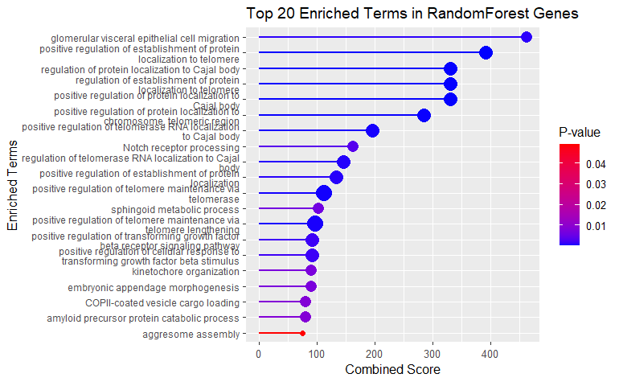

```r
# 1. Random Forest
# Sort the entire dataframe by Combined Score in descending order
sorted_by_score <- enrichment_results_forest[[1]][order(-enrichment_results_forest[[1]]$Combined.Score), ]
# Extract the top 10 terms
top_10_terms_by_score <- head(sorted_by_score, 20)
# Count the number of genes for each term
top_10_terms_by_score$GeneCount <- sapply(strsplit(top_10_terms_by_score$Genes, ";"), length)

# Remove GO identifiers
top_10_terms_by_score$Term <- gsub("\\s*\\(GO:[0-9]+\\)", "", top_10_terms_by_score$Term)
# wrap text
top_10_terms_by_score$ShortTerm <- str_wrap(top_10_terms_by_score$Term, width = 50)

# Create the plot
ggplot(top_10_terms_by_score, aes(x=reorder(ShortTerm, Combined.Score), y=Combined.Score)) +
  geom_segment(aes(x=reorder(ShortTerm, Combined.Score),
                   xend=reorder(ShortTerm, Combined.Score),
                   y=0, yend=Combined.Score, color=P.value), linewidth=0.7) +
  geom_point(aes(color=P.value, size=GeneCount), shape=16) +
  scale_color_gradient(low = "blue", high = "red") +
  scale_size(range = c(2, 6),guide = "none", breaks = seq(1, max(top_10_terms_by_score$GeneCount), by = 1)) +
  coord_flip() +
  theme_gray() +
  theme(axis.text.y = element_text(size = 8)) +
  xlab("Enriched Terms") +
  ylab("Combined Score") +
  ggtitle("Top 20 Enriched Terms in RandomForest Genes") +
  labs(color = "P-value")
```

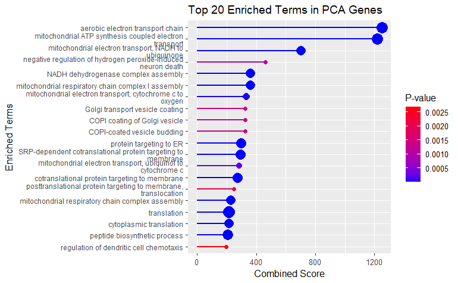

```r
# 1. PCA
# Sort the PCA enrichment results dataframe by Combined Score in descending order
sorted_by_score_pca <- enrichment_results_pca[[1]][order(-enrichment_results_pca[[1]]$Combined.Score), ]
# Extract the top 10 terms from the sorted PCA results
top_10_terms_by_score_pca <- head(sorted_by_score_pca, 20)
# Count the number of genes for each term in the PCA results
top_10_terms_by_score_pca$GeneCount <- sapply(strsplit(top_10_terms_by_score_pca$Genes, ";"), length)
# Remove GO identifiers from PCA terms
top_10_terms_by_score_pca$Term <- gsub("\\s*\\(GO:[0-9]+\\)", "", top_10_terms_by_score_pca$Term)
# Wrap text for PCA terms
top_10_terms_by_score_pca$ShortTerm <- str_wrap(top_10_terms_by_score_pca$Term, width = 50)

# Create the plot for PCA results
ggplot(top_10_terms_by_score_pca, aes(x=reorder(ShortTerm, Combined.Score), y=Combined.Score)) +
  geom_segment(aes(x=reorder(ShortTerm, Combined.Score),
                   xend=reorder(ShortTerm, Combined.Score),
                   y=0, yend=Combined.Score, color=P.value), linewidth=0.7) +
  geom_point(aes(color=P.value, size=GeneCount), shape=16) +
  scale_color_gradient(low = "blue", high = "red") +
  scale_size(range = c(2, 6), guide = "none", breaks = seq(1, max(top_10_terms_by_score_pca$GeneCount), by = 1)) +
  coord_flip() +
  theme_gray() +
  theme(axis.text.y = element_text(size = 8)) +
  xlab("Enriched Terms") +
  ylab("Combined Score") +
  ggtitle("Top 20 Enriched Terms in PCA Genes") +
  labs(color = "P-value")
```

```r
NA
NA
```

## Gene Set Enrichment Analysis (GSEA)

Load and prepare data

```r
# Load the DESeq2 results
deseq2_results <- read.csv("Data/DESeq2_results.csv")

# Create the ranked list of genes and set gene names as the names of the vector
ranked_genes <- deseq2_results$log2FoldChange
names(ranked_genes) <- deseq2_results$X

head(ranked_genes)
```

```
       A1BG    A1BG-AS1        A1CF         A2M     A2M-AS1       A2ML1
-0.48093033  0.07770887  0.26456544 -0.52064014 -0.83370459  0.39791486
```

Get Gene Sets

```r
# Get MSigDB gene sets for Homo sapiens
msigdbr_df <- msigdbr(species = "Homo sapiens", category = "C2")  # C2: curated gene sets

# divide data into a list of gene sets
gene_sets = split(x = msigdbr_df$gene_symbol, f = msigdbr_df$gs_name)
```

Run GSEA

```r
# Run GSEA
fgsea_results <- fgsea(pathways = gene_sets, stats = ranked_genes)
```

Plot results

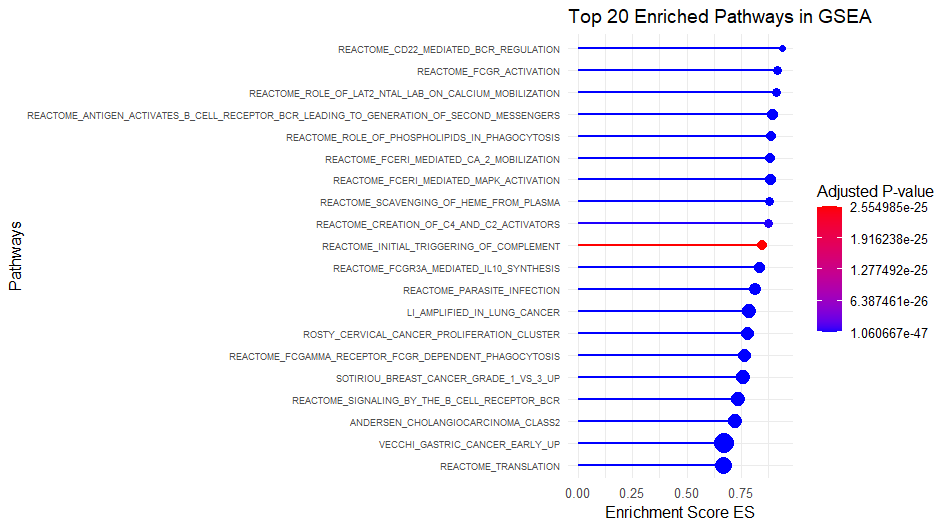

```r
# Sort the GSEA results dataframe by NES or p-value in descending order
sorted_gsea_results <- fgsea_results[order(-abs(fgsea_results$NES)), ]

# Extract the top 20 pathways from the sorted GSEA results
top_gsea_results <- head(sorted_gsea_results, 20)
# Wrap labels
top_gsea_results$ShortPathway <- str_wrap(top_gsea_results$pathway, width = 10)


# Create the plot
ggplot(top_gsea_results, aes(x = reorder(ShortPathway, ES), y = ES)) +
    geom_segment(aes(xend = reorder(ShortPathway, ES), y = 0, yend = ES, color = padj), size = 0.7) +
    geom_point(aes(color = padj, size = size)) +
    scale_color_gradient(low = "blue", high = "red") +
    scale_size(range = c(2, 6), guide = "none") +
    coord_flip() +
    theme_minimal() +
    theme(axis.text.y = element_text(size = 6)) +
    xlab("Pathways") +
    ylab("Enrichment Score ES") +
    ggtitle("Top 20 Enriched Pathways in GSEA") +
    labs(color = "Adjusted P-value")
```

## Comparison of Statistical Power

Create new df to compare results

```r
pca_terms <- sorted_by_score_pca[, c("Term", "Adjusted.P.value")]
gsea_terms <- sorted_gsea_results[, c("pathway", "padj")]
forest_terms <- sorted_by_score[, c("Term", "Adjusted.P.value")]

#Rename columns
names(pca_terms) <- c("PCA_Term", "PCA_Adj_Pval")
names(gsea_terms) <- c("GSEA_Pathway", "GSEA_Adj_Pval")
names(forest_terms) <- c("Forest_Term", "Forest_Adj_Pval")

#combine
max_rows <- max(nrow(pca_terms), nrow(gsea_terms), nrow(forest_terms))
pca_terms[max_rows, ] <- NA
gsea_terms[max_rows, ] <- NA
forest_terms[max_rows, ] <- NA
combined_df <- cbind(pca_terms, gsea_terms, forest_terms)
```

Histogram

```r
# Convert the data frame to long format for ggplot
long_df <- melt(combined_df,
                measure.vars = c("PCA_Adj_Pval", "GSEA_Adj_Pval", "Forest_Adj_Pval"),
                variable.name = "Method",
                value.name = "Adj_Pval")

# Simplify Method names for readability
long_df$Method <- gsub("_Adj_Pval", "", long_df$Method)

# Filter data for significance and create the summary table
pvalue_threshold <- 0.05
pca_terms_significant <- pca_terms[!is.na(pca_terms$PCA_Adj_Pval) & pca_terms$PCA_Adj_Pval <= pvalue_threshold, ]
gsea_terms_significant <- gsea_terms[!is.na(gsea_terms$GSEA_Adj_Pval) & gsea_terms$GSEA_Adj_Pval <= pvalue_threshold, ]
forest_terms_significant <- forest_terms[!is.na(forest_terms$Forest_Adj_Pval) & forest_terms$Forest_Adj_Pval <= pvalue_threshold, ]

summary_table <- data.frame(
  Method = c("PCA + EnrichR", "GSEA", "Random Forest + EnrichR"),
  Significant_Pathways = c(nrow(pca_terms_significant),
                           nrow(gsea_terms_significant),
                           nrow(forest_terms_significant))
)

# Print the summary table
print(summary_table)
```

| Method | Significant_Pathways |
| --- | --- |
| PCA + EnrichR | 59 |
| GSEA | 1619 |
| Random Forest + EnrichR | 4 |

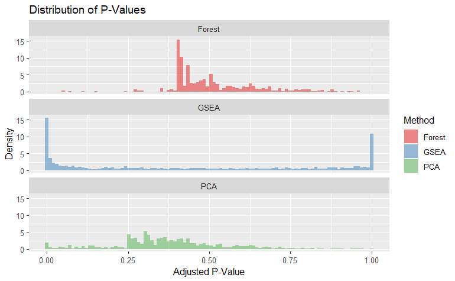

```r
# Histogram
histogram_plot_facet_vertical <- ggplot(long_df, aes(x = Adj_Pval, fill = Method)) +
  geom_histogram(aes(y = ..density..), alpha = 0.5, bins = 100) +
  scale_fill_brewer(palette = "Set1") +
  facet_wrap(~ Method, nrow = 3) +  # Arrange facets vertically
  theme_grey() +
  labs(x = "Adjusted P-Value", y = "Density", fill = "Method") +
  ggtitle("Distribution of P-Values ")

print(histogram_plot_facet_vertical)
```

```r
NA
NA
```